# Two years of an online gift shop, in plain SQL

A UK online retailer that sells giftware, mostly to wholesale customers: **1 million order lines, 53,000 invoices and 5,900 known customers from December 2009 to December 2011**. Eight business questions answered in SQL only: monthly revenue with returns (`LAG`), a Pareto of customers (`NTILE`), RFM segmentation, **cohort retention** by first-purchase month, a market-basket self-join with *lift*, and the time between a customer's orders (`LAG` over dates). Python only runs the queries and draws the charts.

**Data:** [Online Retail II](https://archive.ics.uci.edu/dataset/502/online+retail+ii) from the UCI Machine Learning Repository (real transactions, CC BY 4.0). Run `python build_db.py` once to download it (about 46 MB) and turn it into a SQLite database, then point `RETAIL_DB` at that file.

**Reading the data.** Invoices starting with `C` are cancellations (returns), non-product codes such as `POST` and `BANK CHARGES` are ignored, and about 22% of lines have no customer ID, so the customer-level questions cover only identified customers.

```python
import os
import sqlite3
from pathlib import Path

import matplotlib.pyplot as plt
import numpy as np
import pandas as pd

DB_PATH = Path(os.environ.get("RETAIL_DB", "retail.db"))
AMBER, BLUE, GREY = "#e8a33d", "#2b6cb0", "#a0aec0"
plt.rcParams.update({"axes.spines.top": False, "axes.spines.right": False, "axes.grid": True,
                     "grid.alpha": 0.25, "figure.dpi": 110})
pd.set_option("display.width", 120)
pd.set_option("display.max_columns", 20)

con = sqlite3.connect(DB_PATH)


def q(sql):
    """Run a query and return the result as a DataFrame."""
    return pd.read_sql_query(sql, con)
```

## 0. What is in the database?

```python
tables = q("SELECT name FROM sqlite_master WHERE type = 'table' ORDER BY name").name
pd.DataFrame({"table": tables,
              "rows": [con.execute(f'SELECT COUNT(*) FROM "{t}"').fetchone()[0] for t in tables]})
```

|  | table | rows |
| --- | --- | --- |
| 0 | invoice_lines | 1044848 |

## 1. How do sales and returns develop month by month?

Conditional aggregation separates sales from cancellations in a single pass, and `LAG()` adds the growth versus the previous month. The data ends on 9 December 2011, so that incomplete month is left out.

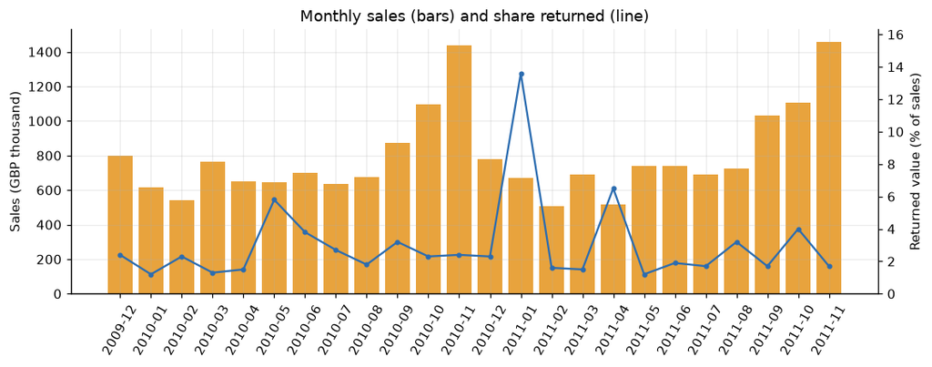

|  | month | orders | sales | returned | returned_pct | growth_pct |
| --- | --- | --- | --- | --- | --- | --- |
| 16 | 2011-04 | 1493 | 516195.0 | 33317.0 | 6.5 | -25.3 |
| 17 | 2011-05 | 1836 | 741154.0 | 8948.0 | 1.2 | 43.6 |
| 18 | 2011-06 | 1675 | 738752.0 | 13761.0 | 1.9 | -0.3 |
| 19 | 2011-07 | 1626 | 689290.0 | 11409.0 | 1.7 | -6.7 |
| 20 | 2011-08 | 1434 | 725494.0 | 22930.0 | 3.2 | 5.3 |
| 21 | 2011-09 | 1973 | 1030469.0 | 17045.0 | 1.7 | 42.0 |
| 22 | 2011-10 | 2240 | 1106667.0 | 43992.0 | 4.0 | 7.4 |
| 23 | 2011-11 | 3001 | 1457742.0 | 25011.0 | 1.7 | 31.7 |

```python
monthly = q("""
WITH monthly AS (
    SELECT strftime('%Y-%m', invoice_date)                                         AS month,
           COUNT(DISTINCT CASE WHEN invoice NOT LIKE 'C%' THEN invoice END)        AS orders,
           SUM(CASE WHEN invoice NOT LIKE 'C%' THEN quantity * price END)          AS sales,
           -SUM(CASE WHEN invoice LIKE 'C%'    THEN quantity * price END)          AS returned
    FROM invoice_lines
    WHERE stock_code GLOB '[0-9][0-9][0-9][0-9][0-9]*' AND invoice_date < '2011-12-01'
    GROUP BY month
)
SELECT month, orders,
       ROUND(sales)                                    AS sales,
       ROUND(returned)                                 AS returned,
       ROUND(100.0 * returned / sales, 1)              AS returned_pct,
       ROUND(100.0 * (sales - LAG(sales) OVER (ORDER BY month))
                   / LAG(sales) OVER (ORDER BY month), 1) AS growth_pct
FROM monthly
ORDER BY month
""")

fig, ax = plt.subplots(figsize=(10, 4))
ax.bar(monthly.month, monthly.sales / 1000, color=AMBER)
ax.set_ylabel("Sales (GBP thousand)")
ax.tick_params(axis="x", rotation=60)
ax2 = ax.twinx()
ax2.plot(monthly.month, monthly.returned_pct, color=BLUE, marker="o", ms=3)
ax2.set_ylabel("Returned value (% of sales)")
ax2.set_ylim(0, max(10, monthly.returned_pct.max() * 1.2))
ax2.grid(False)
ax2.spines["right"].set_visible(True)
ax.set_title("Monthly sales (bars) and share returned (line)")
fig.tight_layout()
plt.show()
monthly.tail(8)
```

## 2. Which products bring in the most money?

Revenue here is **net of returns** (cancellations carry negative quantities), so a big order that was later cancelled does not count. Descriptions are messy in this data (staff typed notes like "damaged" or "test" into them), so each product is labelled with its *most frequent* description, found with `ROW_NUMBER()` over the description counts.

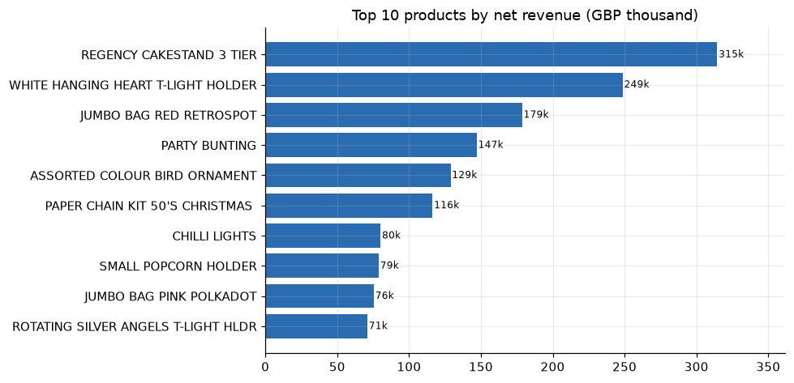

|  | stock_code | product | net_units | orders | net_revenue |
| --- | --- | --- | --- | --- | --- |
| 0 | 22423 | REGENCY CAKESTAND 3 TIER | 24735 | 3931 | 314513.0 |
| 1 | 85123A | WHITE HANGING HEART T-LIGHT HOLDER | 94243 | 5373 | 248679.0 |
| 2 | 85099B | JUMBO BAG RED RETROSPOT | 94325 | 3995 | 178719.0 |
| 3 | 47566 | PARTY BUNTING | 27129 | 2679 | 147157.0 |
| 4 | 84879 | ASSORTED COLOUR BIRD ORNAMENT | 79189 | 2810 | 128907.0 |
| 5 | 22086 | PAPER CHAIN KIT 50'S CHRISTMAS | 34476 | 2020 | 116422.0 |
| 6 | 79321 | CHILLI LIGHTS | 15729 | 1151 | 80237.0 |
| 7 | 22197 | SMALL POPCORN HOLDER | 78007 | 2331 | 78936.0 |
| 8 | 22386 | JUMBO BAG PINK POLKADOT | 38985 | 2245 | 75518.0 |
| 9 | 84347 | ROTATING SILVER ANGELS T-LIGHT HLDR | 21425 | 761 | 71031.0 |

```python
products = q("""
WITH names AS (
    SELECT stock_code, description
    FROM (SELECT stock_code, description,
                 ROW_NUMBER() OVER (PARTITION BY stock_code ORDER BY COUNT(*) DESC) AS rn
          FROM invoice_lines
          WHERE description IS NOT NULL
          GROUP BY stock_code, description)
    WHERE rn = 1
)
SELECT l.stock_code,
       n.description                       AS product,
       SUM(l.quantity)                     AS net_units,
       COUNT(DISTINCT CASE WHEN l.invoice NOT LIKE 'C%' THEN l.invoice END) AS orders,
       ROUND(SUM(l.quantity * l.price))    AS net_revenue
FROM invoice_lines l
JOIN names n USING (stock_code)
WHERE l.stock_code GLOB '[0-9][0-9][0-9][0-9][0-9]*'
GROUP BY l.stock_code
ORDER BY net_revenue DESC
LIMIT 10
""")

fig, ax = plt.subplots(figsize=(9, 4.4))
ax.barh(products["product"][::-1], products.net_revenue[::-1] / 1000, color=BLUE)
for y, v in enumerate(products.net_revenue[::-1] / 1000):
    ax.text(v + 1, y, f"{v:,.0f}k", va="center", fontsize=8)
ax.set_xlim(0, products.net_revenue.max() / 1000 * 1.15)
ax.set_title("Top 10 products by net revenue (GBP thousand)")
fig.tight_layout()
plt.show()
products
```

## 3. How much does the business depend on the UK?

`SUM(revenue) OVER ()` turns each country's revenue into a share, and `RANK()` orders the countries. Customers are counted only where an ID exists.

```python
countries = q("""
WITH by_country AS (
    SELECT country,
           COUNT(DISTINCT customer_id)  AS customers,
           COUNT(DISTINCT invoice)      AS orders,
           SUM(quantity * price)        AS revenue
    FROM invoice_lines
    WHERE invoice NOT LIKE 'C%' AND stock_code GLOB '[0-9][0-9][0-9][0-9][0-9]*'
    GROUP BY country
)
SELECT RANK() OVER (ORDER BY revenue DESC)              AS rank,
       country, customers, orders,
       ROUND(revenue)                                   AS revenue,
       ROUND(100.0 * revenue / SUM(revenue) OVER (), 1) AS share_pct,
       ROUND(revenue / orders)                          AS avg_order_value
FROM by_country
ORDER BY revenue DESC
LIMIT 10
""")

countries
```

|  | rank | country | customers | orders | revenue | share_pct | avg_order_value |
| --- | --- | --- | --- | --- | --- | --- | --- |
| 0 | 1 | United Kingdom | 5335 | 41382 | 16855161.0 | 85.6 | 407.0 |
| 1 | 2 | EIRE | 3 | 581 | 623796.0 | 3.2 | 1074.0 |
| 2 | 3 | Netherlands | 22 | 217 | 549775.0 | 2.8 | 2534.0 |
| 3 | 4 | Germany | 107 | 753 | 383848.0 | 1.9 | 510.0 |
| 4 | 5 | France | 93 | 598 | 311288.0 | 1.6 | 521.0 |
| 5 | 6 | Australia | 15 | 89 | 167868.0 | 0.9 | 1886.0 |
| 6 | 7 | Spain | 38 | 144 | 97818.0 | 0.5 | 679.0 |
| 7 | 8 | Switzerland | 22 | 85 | 94047.0 | 0.5 | 1106.0 |
| 8 | 9 | Sweden | 19 | 99 | 86353.0 | 0.4 | 872.0 |
| 9 | 10 | Denmark | 12 | 42 | 67423.0 | 0.3 | 1605.0 |

## 4. Do a few customers pay the bills?

`NTILE(10)` cuts the identified customers into ten equal groups by lifetime spend, and a running `SUM() OVER` accumulates their share of revenue from the best customers downwards.

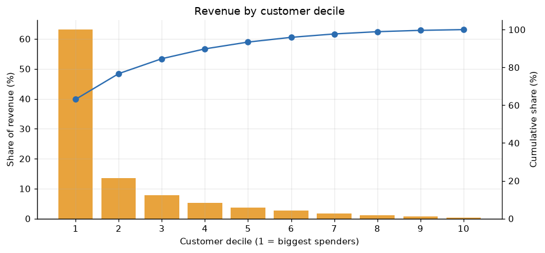

|  | decile | customers | revenue | share_pct | cumulative_pct |
| --- | --- | --- | --- | --- | --- |
| 0 | 1 | 584 | 10360236.0 | 63.1 | 63.1 |
| 1 | 2 | 584 | 2223211.0 | 13.5 | 76.7 |
| 2 | 3 | 583 | 1302150.0 | 7.9 | 84.6 |
| 3 | 4 | 583 | 849456.0 | 5.2 | 89.8 |
| 4 | 5 | 583 | 589373.0 | 3.6 | 93.4 |
| 5 | 6 | 583 | 418699.0 | 2.6 | 95.9 |
| 6 | 7 | 583 | 287023.0 | 1.7 | 97.7 |
| 7 | 8 | 583 | 197082.0 | 1.2 | 98.9 |
| 8 | 9 | 583 | 125971.0 | 0.8 | 99.6 |
| 9 | 10 | 583 | 61669.0 | 0.4 | 100.0 |

```python
deciles = q("""
WITH spend AS (
    SELECT customer_id, SUM(quantity * price) AS lifetime
    FROM invoice_lines
    WHERE customer_id IS NOT NULL AND stock_code GLOB '[0-9][0-9][0-9][0-9][0-9]*'      -- returns are netted off here
    GROUP BY customer_id
    HAVING lifetime > 0
),
bucketed AS (
    SELECT *, NTILE(10) OVER (ORDER BY lifetime DESC) AS decile FROM spend
)
SELECT decile,
       COUNT(*)                                                         AS customers,
       ROUND(SUM(lifetime))                                             AS revenue,
       ROUND(100.0 * SUM(lifetime) / SUM(SUM(lifetime)) OVER (), 1)     AS share_pct,
       ROUND(100.0 * SUM(SUM(lifetime)) OVER (ORDER BY decile)
                   / SUM(SUM(lifetime)) OVER (), 1)                     AS cumulative_pct
FROM bucketed
GROUP BY decile
ORDER BY decile
""")

fig, ax = plt.subplots(figsize=(8.5, 4))
ax.bar(deciles.decile.astype(str), deciles.share_pct, color=AMBER)
ax.set_xlabel("Customer decile (1 = biggest spenders)")
ax.set_ylabel("Share of revenue (%)")
ax2 = ax.twinx()
ax2.plot(deciles.decile.astype(str), deciles.cumulative_pct, color=BLUE, marker="o")
ax2.set_ylim(0, 105)
ax2.set_ylabel("Cumulative share (%)")
ax2.grid(False)
ax2.spines["right"].set_visible(True)
ax.set_title("Revenue by customer decile")
fig.tight_layout()
plt.show()
deciles
```

## 5. Which customers need a phone call? RFM segmentation

**R**ecency, **F**requency and **M**onetary value per customer. `NTILE(4)` scores recency and spend (4 = best), frequency is bucketed with a `CASE`, and a second `CASE` names the segments. "Today" is the day after the last invoice in the data.

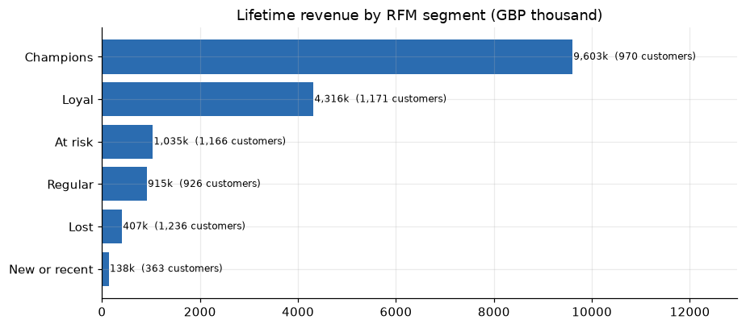

|  | segment | customers | revenue | revenue_share_pct | avg_days_since_last_order | avg_orders |
| --- | --- | --- | --- | --- | --- | --- |
| 0 | Champions | 970 | 9603293.0 | 58.5 | 10.0 | 18.6 |
| 1 | Loyal | 1171 | 4316211.0 | 26.3 | 135.0 | 9.5 |
| 2 | At risk | 1166 | 1035425.0 | 6.3 | 335.0 | 2.7 |
| 3 | Regular | 926 | 914587.0 | 5.6 | 34.0 | 2.9 |
| 4 | Lost | 1236 | 407044.0 | 2.5 | 440.0 | 1.0 |
| 5 | New or recent | 363 | 138313.0 | 0.8 | 43.0 | 1.0 |

```python
rfm = q("""
WITH today AS (SELECT date(MAX(invoice_date), '+1 day') AS d FROM invoice_lines),
customers AS (
    SELECT customer_id,
           CAST(julianday((SELECT d FROM today)) - julianday(MAX(invoice_date)) AS INT) AS recency_days,
           COUNT(DISTINCT CASE WHEN invoice NOT LIKE 'C%' THEN invoice END)              AS orders,
           SUM(quantity * price)                                                         AS monetary
    FROM invoice_lines
    WHERE customer_id IS NOT NULL AND stock_code GLOB '[0-9][0-9][0-9][0-9][0-9]*'
    GROUP BY customer_id
    HAVING monetary > 0
),
scored AS (
    SELECT *,
           NTILE(4) OVER (ORDER BY recency_days DESC) AS r,        -- 4 = bought most recently
           CASE WHEN orders >= 5 THEN 3 WHEN orders >= 2 THEN 2 ELSE 1 END AS f,
           NTILE(4) OVER (ORDER BY monetary)          AS m
    FROM customers
)
SELECT CASE WHEN r = 4 AND f = 3 THEN 'Champions'
            WHEN f = 3           THEN 'Loyal'
            WHEN r >= 3 AND f = 1 THEN 'New or recent'
            WHEN r <= 2 AND f >= 2 THEN 'At risk'
            WHEN r <= 2          THEN 'Lost'
            ELSE                      'Regular' END                AS segment,
       COUNT(*)                                                    AS customers,
       ROUND(SUM(monetary))                                        AS revenue,
       ROUND(100.0 * SUM(monetary) / SUM(SUM(monetary)) OVER (), 1) AS revenue_share_pct,
       ROUND(AVG(recency_days))                                    AS avg_days_since_last_order,
       ROUND(AVG(orders), 1)                                       AS avg_orders
FROM scored
GROUP BY segment
ORDER BY revenue DESC
""")

fig, ax = plt.subplots(figsize=(8.5, 3.8))
ax.barh(rfm.segment[::-1], rfm.revenue[::-1] / 1000, color=BLUE)
for y, (v, n) in enumerate(zip(rfm.revenue[::-1] / 1000, rfm.customers[::-1])):
    ax.text(v + 20, y, f"{v:,.0f}k  ({n:,} customers)", va="center", fontsize=8)
ax.set_xlim(0, rfm.revenue.max() / 1000 * 1.35)
ax.set_title("Lifetime revenue by RFM segment (GBP thousand)")
fig.tight_layout()
plt.show()
rfm
```

## 6. Do customers keep coming back? Cohort retention

Customers are grouped by the month of their first purchase. For each cohort the query counts how many are active again 1, 2, 3... months later. Retention is that count divided by the cohort size. The first data month holds everyone who already existed in December 2009, so cohorts start from January 2010.

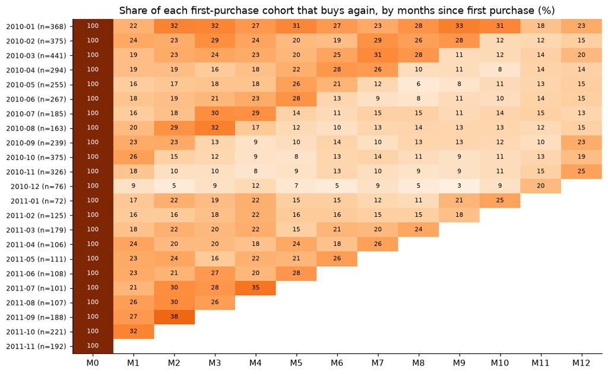

```python
cohorts = q("""
WITH purchases AS (
    SELECT DISTINCT customer_id, strftime('%Y-%m', invoice_date) AS month
    FROM invoice_lines
    WHERE customer_id IS NOT NULL AND invoice NOT LIKE 'C%' AND stock_code GLOB '[0-9][0-9][0-9][0-9][0-9]*'
      AND invoice_date < '2011-12-01'          -- December 2011 is incomplete
),
first_month AS (
    SELECT customer_id, MIN(month) AS cohort FROM purchases GROUP BY customer_id
),
cohort_size AS (
    SELECT cohort, COUNT(*) AS size FROM first_month GROUP BY cohort
)
SELECT f.cohort,
       cs.size                                    AS customers,
       (CAST(substr(p.month, 1, 4) AS INT) - CAST(substr(f.cohort, 1, 4) AS INT)) * 12
         + CAST(substr(p.month, 6, 2) AS INT) - CAST(substr(f.cohort, 6, 2) AS INT) AS months_since,
       COUNT(*)                                   AS active_customers,
       ROUND(100.0 * COUNT(*) / cs.size, 1)       AS retention_pct
FROM first_month f
JOIN purchases   p  USING (customer_id)
JOIN cohort_size cs ON cs.cohort = f.cohort
WHERE f.cohort >= '2010-01'
GROUP BY f.cohort, months_since
ORDER BY f.cohort, months_since
""")

grid = cohorts[cohorts.months_since <= 12].pivot(index="cohort", columns="months_since", values="retention_pct")
sizes = cohorts.drop_duplicates("cohort").set_index("cohort").customers
fig, ax = plt.subplots(figsize=(10, 6.2))
ax.imshow(grid.values, cmap="Oranges", vmin=0, vmax=60, aspect="auto")
ax.set_xticks(range(grid.shape[1]), [f"M{c}" for c in grid.columns])
ax.set_yticks(range(grid.shape[0]), [f"{c} (n={sizes[c]})" for c in grid.index], fontsize=8)
for i in range(grid.shape[0]):
    for j in range(grid.shape[1]):
        v = grid.values[i, j]
        if not np.isnan(v):
            ax.text(j, i, f"{v:.0f}", ha="center", va="center", fontsize=7, color="white" if v >= 90 else "black")
ax.grid(False)
ax.set_title("Share of each first-purchase cohort that buys again, by months since first purchase (%)")
fig.tight_layout()
plt.show()
```

## 7. Which products are bought together?

A **self-join** of the basket table pairs up products on the same invoice. To keep it fast it looks at the 60 products that appear on the most invoices. *Lift* compares how often a pair occurs with how often it would occur if the two products were bought independently (above 1 means they go together).

```python
basket = q("""
WITH names AS (
    SELECT stock_code, description
    FROM (SELECT stock_code, description,
                 ROW_NUMBER() OVER (PARTITION BY stock_code ORDER BY COUNT(*) DESC) AS rn
          FROM invoice_lines
          WHERE description IS NOT NULL
          GROUP BY stock_code, description)
    WHERE rn = 1
),
top_products AS (
    SELECT stock_code
    FROM invoice_lines
    WHERE invoice NOT LIKE 'C%' AND stock_code GLOB '[0-9][0-9][0-9][0-9][0-9]*'
    GROUP BY stock_code
    ORDER BY COUNT(DISTINCT invoice) DESC
    LIMIT 60
),
baskets AS (
    SELECT DISTINCT invoice, stock_code
    FROM invoice_lines
    WHERE invoice NOT LIKE 'C%' AND stock_code IN (SELECT stock_code FROM top_products)
),
total AS (SELECT COUNT(DISTINCT invoice) AS n FROM invoice_lines WHERE invoice NOT LIKE 'C%'),
single AS (SELECT stock_code, COUNT(*) AS invoices FROM baskets GROUP BY stock_code),
pairs AS (
    SELECT a.stock_code AS a_code, b.stock_code AS b_code, COUNT(*) AS together
    FROM baskets a
    JOIN baskets b ON a.invoice = b.invoice AND a.stock_code < b.stock_code
    GROUP BY a.stock_code, b.stock_code
)
SELECT na.description                                              AS product_a,
       nb.description                                              AS product_b,
       p.together                                                  AS orders_together,
       ROUND(1.0 * p.together * t.n / (sa.invoices * sb.invoices), 1) AS lift
FROM pairs p
CROSS JOIN total t
JOIN names na ON na.stock_code = p.a_code
JOIN names nb ON nb.stock_code = p.b_code
JOIN single sa ON sa.stock_code = p.a_code
JOIN single sb ON sb.stock_code = p.b_code
WHERE p.together >= 200
ORDER BY lift DESC
LIMIT 10
""")

basket
```

|  | product_a | product_b | orders_together | lift |
| --- | --- | --- | --- | --- |
| 0 | RED RETROSPOT CHARLOTTE BAG | CHARLOTTE BAG PINK POLKADOT | 1078 | 15.1 |
| 1 | SWEETHEART CERAMIC TRINKET BOX | STRAWBERRY CERAMIC TRINKET BOX | 1109 | 13.9 |
| 2 | WOODLAND CHARLOTTE BAG | CHARLOTTE BAG SUKI DESIGN | 839 | 13.8 |
| 3 | WOODLAND CHARLOTTE BAG | CHARLOTTE BAG PINK POLKADOT | 764 | 13.8 |
| 4 | JUMBO BAG SCANDINAVIAN PAISLEY | JUMBO BAG PINK VINTAGE PAISLEY | 757 | 13.7 |
| 5 | CHARLOTTE BAG SUKI DESIGN | CHARLOTTE BAG PINK POLKADOT | 835 | 13.6 |
| 6 | WOODLAND CHARLOTTE BAG | RED RETROSPOT CHARLOTTE BAG | 928 | 13.1 |
| 7 | CHOCOLATE HOT WATER BOTTLE | HOT WATER BOTTLE TEA AND SYMPATHY | 776 | 12.9 |
| 8 | WOODEN PICTURE FRAME WHITE FINISH | WOODEN FRAME ANTIQUE WHITE | 1078 | 12.3 |
| 9 | RED RETROSPOT CHARLOTTE BAG | CHARLOTTE BAG SUKI DESIGN | 961 | 12.2 |

## 8. How long do customers wait between orders?

`LAG(order_date)` over each customer's invoices puts the previous order date on the same row, so the gap is a subtraction. A `CASE` then sorts the gaps into time buckets.

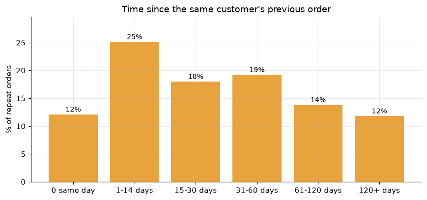

|  | gap | orders | share_pct |
| --- | --- | --- | --- |
| 0 | 0 same day | 3717 | 12.1 |
| 1 | 1-14 days | 7730 | 25.1 |
| 2 | 15-30 days | 5526 | 18.0 |
| 3 | 31-60 days | 5891 | 19.2 |
| 4 | 61-120 days | 4240 | 13.8 |
| 5 | 120+ days | 3640 | 11.8 |

```python
gaps = q("""
WITH orders AS (
    SELECT customer_id, invoice, MIN(date(invoice_date)) AS order_date
    FROM invoice_lines
    WHERE customer_id IS NOT NULL AND invoice NOT LIKE 'C%' AND stock_code GLOB '[0-9][0-9][0-9][0-9][0-9]*'
    GROUP BY customer_id, invoice
),
gaps AS (
    SELECT julianday(order_date)
             - julianday(LAG(order_date) OVER (PARTITION BY customer_id ORDER BY order_date)) AS gap_days
    FROM orders
)
SELECT CASE WHEN gap_days = 0   THEN '0 same day'
            WHEN gap_days <= 14 THEN '1-14 days'
            WHEN gap_days <= 30 THEN '15-30 days'
            WHEN gap_days <= 60 THEN '31-60 days'
            WHEN gap_days <= 120 THEN '61-120 days'
            ELSE                      '120+ days' END AS gap,
       COUNT(*)                                        AS orders,
       ROUND(100.0 * COUNT(*) / SUM(COUNT(*)) OVER (), 1) AS share_pct
FROM gaps
WHERE gap_days IS NOT NULL
GROUP BY gap
ORDER BY MIN(gap_days)
""")

fig, ax = plt.subplots(figsize=(8, 3.8))
ax.bar(gaps.gap, gaps.share_pct, color=AMBER)
for x, v in enumerate(gaps.share_pct):
    ax.text(x, v + 0.5, f"{v:.0f}%", ha="center", fontsize=9)
ax.set_ylim(0, gaps.share_pct.max() * 1.18)
ax.set_title("Time since the same customer's previous order")
ax.set_ylabel("% of repeat orders")
fig.tight_layout()
plt.show()
gaps
```

## What the queries say

- **It is a seasonal wholesale business.** Sales jump in September to November (£1.44M in November 2010 and £1.46M in November 2011, about double a typical £0.65-0.75M month) and fall straight back afterwards, with December 2010 down 46%. That is the shape of shops stocking up for Christmas. Returns are small, between about 1% and 6% of sales in most months, with one outlier in January 2011 (13.6%).
- **The UK is 85.6% of revenue**, but the other markets are different in kind: Ireland has just 3 identified customers with an average order of £1,074, and the 22 Dutch customers average £2,534 per order, about six times the UK's £407. Those look like a few large trade buyers.
- **Revenue is very concentrated.** The top 10% of customers (584 of them) bring in 63% of revenue, the top 20% bring in 77%, and the entire bottom half together adds up to just 6.6%.
- **RFM puts a number on the "worth a call" group.** 970 Champions (about 17% of identified customers) generate 58.5% of revenue. The At-risk segment is 1,166 customers who ordered at least twice but have been silent for about 335 days on average, together worth £1.0M in lifetime revenue. The 1,236 Lost customers ordered once and never came back.
- **Roughly one new customer in five returns the next month.** Averaged over all cohorts, 21% buy again one month after their first purchase and the figure drifts down to the low-to-mid teens after ten months. Cohorts from the second half of 2010 hold on noticeably worse than the early-2010 ones.
- **Products bought together are variants of one line.** The highest lifts (12 to 15) are different designs of the same item, such as Charlotte bags, jumbo bags and ceramic trinket boxes. A lift of 15 means the pair appears together 15 times more often than if the two were bought independently.
- **Reorders come fast or not at all.** 12% of repeat orders are placed on the same day as the previous one, 37% within two weeks and 55% within 30 days, while 12% take more than 120 days.

**Limits:** about 22% of order lines have no customer ID, so the customer-level numbers cover identified customers only; the data ends on 9 December 2011, so December 2011 is excluded; some product descriptions in the source contain staff notes, which is why products are labelled by their most frequent description.

**Techniques covered:** conditional aggregation, `LAG`, `NTILE`, `ROW_NUMBER`, `RANK`, running totals, CTE chains, a self-join with lift, date arithmetic and `CASE` bucketing.